# Machine Learning & Statistical Data Mining with R

The node 20 has been chosen:

```r
library(tree)
set.seed(1)

#Print the tree as a textouput
OJ.tree
```

```
## node), split, n, deviance, yval, (yprob)
##       * denotes terminal node
##
##  1) root 800 1064.00 CH ( 0.61750 0.38250 )
##    2) LoyalCH < 0.508643 350  409.30 MM ( 0.27143 0.72857 )
##      4) LoyalCH < 0.264232 166  122.10 MM ( 0.12048 0.87952 )
##        8) LoyalCH < 0.0356415 57   10.07 MM ( 0.01754 0.98246 ) *
##        9) LoyalCH > 0.0356415 109  100.90 MM ( 0.17431 0.82569 ) *
##      5) LoyalCH > 0.264232 184  248.80 MM ( 0.40761 0.59239 )
##       10) PriceDiff < 0.195 83   91.66 MM ( 0.24096 0.75904 )
##         20) SpecialCH < 0.5 70   60.89 MM ( 0.15714 0.84286 ) *
##         21) SpecialCH > 0.5 13   16.05 CH ( 0.69231 0.30769 ) *
##       11) PriceDiff > 0.195 101  139.20 CH ( 0.54455 0.45545 ) *
##    3) LoyalCH > 0.508643 450  318.10 CH ( 0.88667 0.11333 )
##      6) LoyalCH < 0.764572 172  188.90 CH ( 0.76163 0.23837 )
##       12) ListPriceDiff < 0.235 70   95.61 CH ( 0.57143 0.42857 ) *
##       13) ListPriceDiff > 0.235 102   69.76 CH ( 0.89216 0.10784 ) *
##      7) LoyalCH > 0.764572 278   86.14 CH ( 0.96403 0.03597 ) *
```

```r
#Set the training and test dataset
train = sample(dim(OJ)[1], dim(OJ)[1] *0.5)
OJ.train = OJ[train, ] #50% training data
OJ.test = OJ[-train, ] #50% test data
```

4. Create a plot of three and interpret the results.

Out of the 8 nodes, 5 nodes are CH and the 3 others are MM. High level analysis: when the LoyalCH is greater or equal to 0.264232 and strictly less than 0.508643, two nodes predict CH, and one node predict MM.

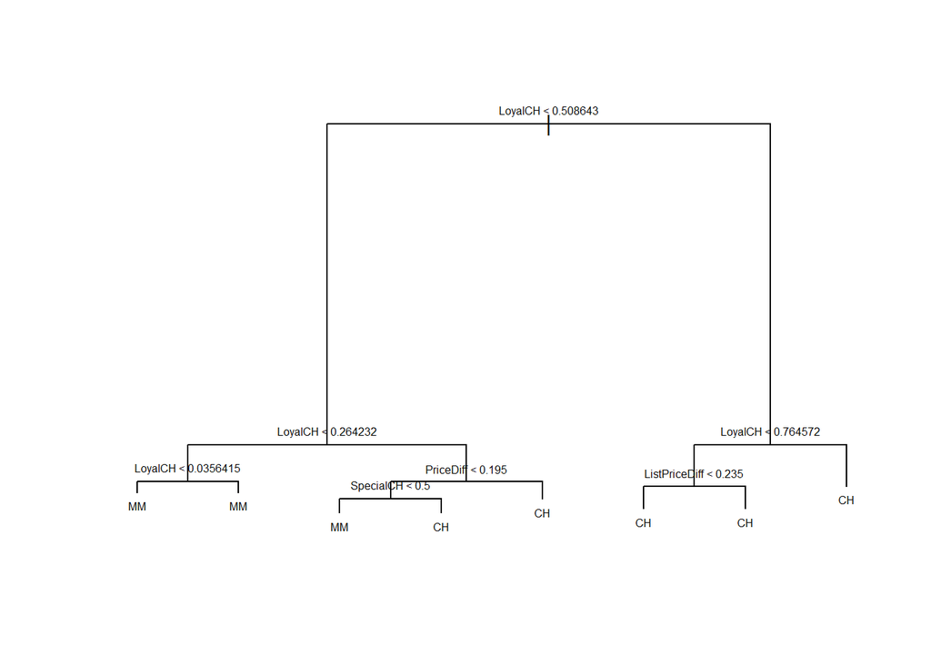

```r
library(tree)
set.seed(1)
plot(OJ.tree)
text(OJ.tree, pretty = 0, cex=0.5)
```

5. Predict the response on the test data, and produce a confusion matrix comparing the test labels to the predicted test labels. Provide the test error rate.

This model test error rate is 20%.

```r
library(tree)
set.seed(1)
#Test MSE
OJ.pred = predict(OJ.tree, OJ.test, type = "class")
table(OJ.test$Purchase, OJ.pred)
```

```
##     OJ.pred
##       CH  MM
##   CH 304  26
##   MM  81 124
```

```r
cat ("Test error: ", 100 * (26+81)/(304+124+81+26), '%', sep="" )
```

```
## Test error: 20.0%
```

6. Apply the cv.tree() function to the training set in order to determine the optimal tree size.

Looking at the results of cv.oj, the tree with 2 terminal nodes has the lowest cross-validation classification, and the lowest complexity level, with 100 cross-validation errors.

```r
set.seed(1)
#The function cv.tree()  performs cross-validation in order to determine the optimal level of tree complexity.
#The cost complexity pruning is used in order to select a sequence of trees for consideration.
#The argument 'rune.misclass' is used to indicate that the classification error rate should guide the cross-validation
#and pruning process, rather than the default for cv.tree() function, which is the deviance.
cv.oj = cv.tree(OJ.tree, FUN = prune.misclass)
cv.oj
```

```
## $size
## [1] 8 5 2 1
##
## $dev
## [1] 100 100 100 212
##
## $k
## [1]       -Inf   0.000000   4.666667 160.000000
##
## $method
## [1] "misclass"
##
## attr(,"class")
## [1] "prune"         "tree.sequence"
```

7. Produce a plot with three size on the x-axis and cross-validated classification error rate.

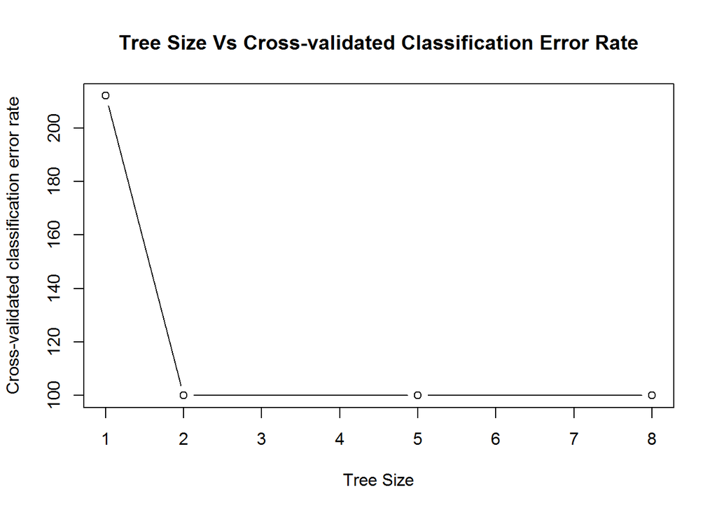

```r
set.seed(1)
plot(cv.oj$size, cv.oj$dev, type = "b", xlab = "Tree Size", ylab = "Cross-validated classification error rate", main="Tree Size Vs Cross-validated Classification Error Rate")
```

8. Which tree size corresponds to the lowest cross-validated classification error rate?

Looking at the graph, it looks like tree sizes 2,5 and 8 have a similar cross-validated classificaiton error rate, at 100. The aim is the reduce complexity of the model and therefore, minimise the tree size. A tree size of 2 is therefore retained. This is the same result as question f).

1. Produce a pruned tree corresponding to the optimal tree size obtained using cross-validation. If the cross-validation does not lead to selection of a pruned tree, then create a pruned tree with 5 terminal nodes.

The tree size set to 2, with cross-validation, does not lead to the selection of a pruned tree (i.e. too much information is lost), therefore the tree has been created with 5 terminal nodes.

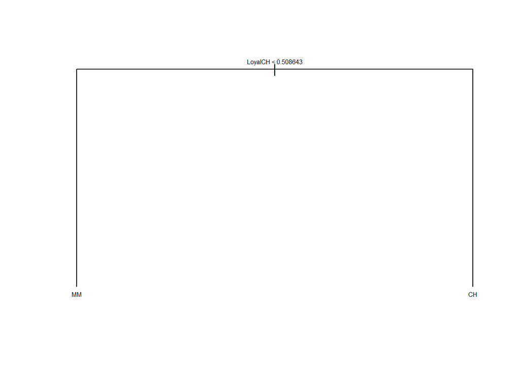

```r
set.seed(1)

#tree size is set to 2
prune.OJ = prune.misclass(OJ.tree, best=2)
plot(prune.OJ)
text(prune.OJ, pretty=0, cex =0.5)
```

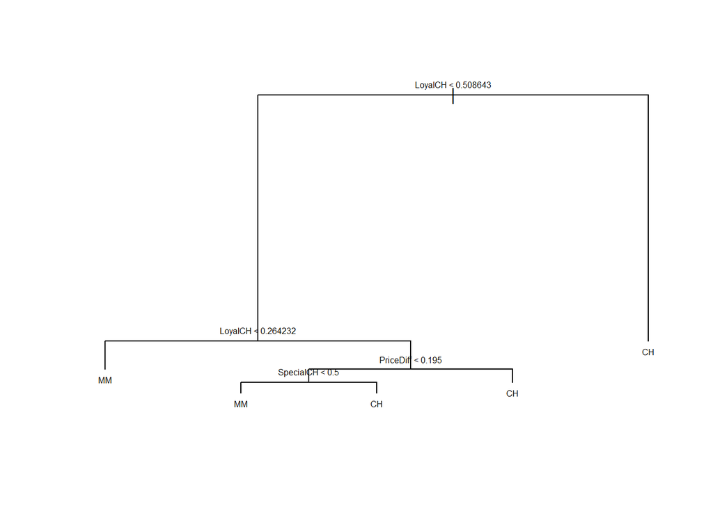

```r
#tree size is set to 5
prune.OJ = prune.misclass(OJ.tree, best=5)
plot(prune.OJ)
text(prune.OJ, pretty=0, cex =0.5)
```

10. Compare the training error rates between the pruned and unpruned trees. Which is better?

The training error rates for the unpruned tree is 16.5%, see question b) above

The training error rate are the same in both cases.

```r
set.seed(1)
summary(OJ.tree)
```

[output not shown]

11. Compare the test error rates between the pruned and unpruned trees. Which is higher?

The test error with a tree size = 5 is 20%

The test error rates are the same with both the unpruned and pruned tree with cross-validation at tree size = 5.

```r
set.seed(1)
OJ.test_pred = predict(prune.OJ,OJ.test, type = "class" )
table(OJ.test$Purchase, OJ.test_pred)
```

```
##     OJ.test_pred
##       CH  MM
##   CH 304  26
##   MM  81 124
```

```r
cat ("Test error: ", 100* (26+81)/(304+124+81+26), '%', sep="" )
```

```
## Test error: 20.0%
```

Conclusion: according to these results, pruning the tree has neither improved the training nor the test error rate. However, pruning has reduced the complexity of the model by reducing the number of node from 8 to 5. Therefore, the pruned model should be preferred.

Exercise 10: In this section, Boosting is used to predict Salary in the Hitters data set

1. Remove the observations for whom the salary information is unknown, and then log-transform the salaries

```r
library(ISLR)
data("Hitters")
#Remove the unknown salary information
Hitters = Hitters[-which(is.na(Hitters$Salary)), ]
#Log transform
Hitters$Salary = log(Hitters$Salary)
```

2. Create a training set of 200 observations, and the test set consisting of the remaining observations

```r
train = 1:200
Hitters.train = Hitters[train, ]
dim(Hitters.train)
```

```
## [1] 200  20
```

```r
Hitters.test = Hitters[-train, ]
dim(Hitters.test)
```

```
## [1] 63 20
```

3. Perform Boosting on the training set with 1,000 trees for a range of values of the shrinkage parameter lambda. Produce a plot with different shrinkage values on the x-axis and the corresponding training set MSE on the y-axis.

[figure not shown]

```r
library(gbm)
set.seed(1)
#Generate a vector of sequence of staring from 0.1 and going to 1.0, with a 0.1 step
seqs = seq(0.1, 1, by = 0.1)
len = length(lambdas)
#Init the training error vector of length 'len' with NA elements
train.errors = rep(NA, len)
for (i in 1:length(lambdas)) {
    #This is a regression problem. Therefore, the distribution is set to "gaussian".
    #The gbm() function fit the salary variable against all other predictors on the training set Hitters.
    #Train with a tree number set to 1000 and an shrinkage element from the lambdas list
    boost.hitters = gbm(Salary ~ ., data = Hitters.train, distribution = "gaussian", n.trees = 1000, shrinkage = lambdas[i])
    #Train the model
    train.pred = predict(boost.hitters, Hitters.train, n.trees = 1000)
    #Generate the training errors
    train.errors[i] = mean((Hitters.train$Salary - train.pred)^2)
}

#Plot the 'lambdas' on the x-axis, the training errors on the y-axis
plot(lambdas, train.errors, type = "b", xlab = "Shrinkage (a.k.a. Lambda)", ylab = "Training MSE", col = "blue", pch =20, main="Boosting on Traning data for the Salary predicted variable (1000 trees)")
```

4. Produce a plot with different shrinkage values on the x-axis and the corresponding test set MSE on the y-axis.

[figure not shown]

```r
library(gbm)
set.seed(1)
#Generate a vector of sequence of staring from 0.1 and going to 1.0, with a 0.1 step
seqs = seq(0.1, 1, by = 0.1)
len = length(lambdas)
#Init the test error vector of length 'len' with NA elements
test.errors = rep(NA, len)
for (i in 1:len) {
    #This is a regression problem. Therefore, the distribution is set to "gaussian".
    #The gbm() function fit the salary variable against all other predictors on the training set Hitters.
    #Train with a tree number set to 1000 and an shrinkage element from the lambdas list
    boost.hitters = gbm(Salary ~ ., data = Hitters.train, distribution = "gaussian", n.trees = 1000, shrinkage = lambdas[i])
    #Test the model
    test.pred = predict(boost.hitters, Hitters.test, n.trees = 1000)
    #Generate the test errors
    test.errors[i] = mean((Hitters.test$Salary - test.pred)^2)
}

#Plot the 'lambdas' on the x-axis, the test errors on the y-axis
plot(lambdas, test.errors, type = "b", xlab = "Shrinkage (a.k.a. Lambda)", ylab = "Test MSE", col = "blue", pch =20, main="Boosting on Test data for the Salary predicted variable (1000 trees)")
```

5. Compare the test MSE of Boosting with the test MSE of the best linear regression model that you can build

The Boosting best test MSE is approximately 25.06%

Now let’s build the best regression model.

Step 1- Use the Backward elimination process on the training dataset, setting the alpha critical at 5%. The process is as follows:

1. Start with all the predictors in the model.
2. Remove the predictor with highest abs(p-value) greater than the defined alpha critical.
3. Re-test the model and goto 2
4. Stop when all abs(p-value) are less than alpha critical.

Step 2- Let’s try to improve on this by adding some interaction on the variables such as square, polynominal and removing the less impacting variables.

General Conclusion: Best linear regression test MSE is 48.87%, whereas the Boosting generates a test MSE of 25.06%. Therefore, Boosting seems to a better model. However, the error rate is quite large.

The details of the steps are provided below:

Step 0 - Generate Boosting test MSE

```r
#######
####### Boosting test MSE
#######
set.seed(1)
Boosting.error = min(test.errors)
paste ("The Boosting test error is:", 100*Boosting.error, "%", sep = " ")
```

```
## [1] "The Boosting test error is: 25.0646292118283 %"
```

Step 1 - Linear Regression Backward selection test MSE

```r
#######
####### Linear Regression Backward selection test MSE
#######
#Start with all variables and check predictors p-values"
lm.fit = lm(formula = Salary ~., data = Hitters.train)
summary(lm.fit)
```

```
##
## Call:
## lm(formula = Salary ~ ., data = Hitters.train)
##
## Residuals:
##      Min       1Q   Median       3Q      Max
## -1.44628 -0.43844  0.02835  0.39266  2.83081
##
## Coefficients:
##               Estimate Std. Error t value Pr(>|t|)
## (Intercept)  4.4531779  0.1953605  22.795  < 2e-16 ***
## AtBat       -0.0041511  0.0015441  -2.688 0.007852 **
## Hits         0.0189964  0.0054505   3.485 0.000618 ***
## HmRun        0.0094426  0.0134247   0.703 0.482728
## Runs        -0.0029961  0.0067142  -0.446 0.655968
## RBI         -0.0026030  0.0056677  -0.459 0.646590
## Walks        0.0113452  0.0039819   2.849 0.004894 **
## Years        0.0686664  0.0259832   2.643 0.008949 **
## CAtBat       0.0001479  0.0002850   0.519 0.604507
## CHits       -0.0012085  0.0014250  -0.848 0.397515
## CHmRun       0.0004085  0.0034671   0.118 0.906335
## CRuns        0.0025268  0.0016188   1.561 0.120299
## CRBI         0.0003625  0.0014589   0.248 0.804062
## CWalks      -0.0016141  0.0006971  -2.316 0.021712 *
## LeagueN      0.1487966  0.1654780   0.899 0.369751
## DivisionW   -0.1359398  0.0880186  -1.544 0.124237
## PutOuts      0.0005631  0.0001856   3.034 0.002770 **
## Assists      0.0008936  0.0005092   1.755 0.080969 .
## Errors      -0.0099497  0.0100046  -0.995 0.321308
## NewLeagueN  -0.0315309  0.1655198  -0.190 0.849135
## ---
## Signif. codes:  0 '***' 0.001 '**' 0.01 '*' 0.05 '.' 0.1 ' ' 1
##
## Residual standard error: 0.5966 on 180 degrees of freedom
## Multiple R-squared:  0.6149, Adjusted R-squared:  0.5743
## F-statistic: 15.13 on 19 and 180 DF,  p-value: < 2.2e-16
```

```r
#Remove highest p-value predictor => CHmRun =  0.906335, check predictors p-values")
lm.fit = lm(formula = Salary ~. - CHmRun, data = Hitters.train)
summary(lm.fit)
```

```
##
## Call:
## lm(formula = Salary ~ . - CHmRun, data = Hitters.train)
##
## Residuals:
##      Min       1Q   Median       3Q      Max
## -1.42940 -0.44832  0.02891  0.39437  2.83084
##
## Coefficients:
##               Estimate Std. Error t value Pr(>|t|)
## (Intercept)  4.4540717  0.1946807  22.879  < 2e-16 ***
## AtBat       -0.0041485  0.0015397  -2.694  0.00772 **
## Hits         0.0190850  0.0053836   3.545  0.00050 ***
## HmRun        0.0100702  0.0122893   0.819  0.41362
## Runs        -0.0032210  0.0064194  -0.502  0.61644
## RBI         -0.0027457  0.0055218  -0.497  0.61963
## Walks        0.0113960  0.0039477   2.887  0.00437 **
## Years        0.0685052  0.0258764   2.647  0.00883 **
## CAtBat       0.0001553  0.0002772   0.560  0.57619
## CHits       -0.0013209  0.0010561  -1.251  0.21265
## CRuns        0.0026485  0.0012428   2.131  0.03443 *
## CRBI         0.0005211  0.0005613   0.928  0.35445
## CWalks      -0.0016372  0.0006671  -2.454  0.01506 *
## LeagueN      0.1473236  0.1645551   0.895  0.37182
## DivisionW   -0.1364689  0.0876642  -1.557  0.12128
## PutOuts      0.0005628  0.0001851   3.041  0.00271 **
## Assists      0.0008897  0.0005067   1.756  0.08082 .
## Errors      -0.0099337  0.0099764  -0.996  0.32071
## NewLeagueN  -0.0302294  0.1647003  -0.184  0.85458
## ---
## Signif. codes:  0 '***' 0.001 '**' 0.01 '*' 0.05 '.' 0.1 ' ' 1
##
## Residual standard error: 0.595 on 181 degrees of freedom
## Multiple R-squared:  0.6149, Adjusted R-squared:  0.5766
## F-statistic: 16.06 on 18 and 181 DF,  p-value: < 2.2e-16
```

```r
#Remove highest p-value predictor. It should be NewLeagueN with 0.84135, but for some reason it does not show in the ?Hittern dataset description. NewLeague will be removed instead as it seems to be the equivalent column
lm.fit = lm(formula = Salary ~. -CHmRun - NewLeague, data = Hitters.train)
summary(lm.fit)
```

```
##
## Call:
## lm(formula = Salary ~ . - CHmRun - NewLeague, data = Hitters.train)
##
## Residuals:
##      Min       1Q   Median       3Q      Max
## -1.43729 -0.44619  0.02989  0.39509  2.82562
##
## Coefficients:
##               Estimate Std. Error t value Pr(>|t|)
## (Intercept)  4.4530409  0.1940824  22.944  < 2e-16 ***
## AtBat       -0.0041681  0.0015319  -2.721 0.007144 **
## Hits         0.0191034  0.0053684   3.559 0.000476 ***
## HmRun        0.0100725  0.0122566   0.822 0.412264
## Runs        -0.0031421  0.0063879  -0.492 0.623396
## RBI         -0.0027376  0.0055070  -0.497 0.619714
## Walks        0.0113427  0.0039265   2.889 0.004338 **
## Years        0.0686123  0.0258010   2.659 0.008529 **
## CAtBat       0.0001568  0.0002764   0.567 0.571182
## CHits       -0.0013394  0.0010485  -1.277 0.203083
## CRuns        0.0026662  0.0012358   2.158 0.032271 *
## CRBI         0.0005271  0.0005588   0.943 0.346834
## CWalks      -0.0016352  0.0006652  -2.458 0.014900 *
## LeagueN      0.1220472  0.0898324   1.359 0.175952
## DivisionW   -0.1366977  0.0874224  -1.564 0.119638
## PutOuts      0.0005630  0.0001846   3.050 0.002628 **
## Assists      0.0008924  0.0005051   1.767 0.078985 .
## Errors      -0.0098005  0.0099235  -0.988 0.324656
## ---
## Signif. codes:  0 '***' 0.001 '**' 0.01 '*' 0.05 '.' 0.1 ' ' 1
##
## Residual standard error: 0.5934 on 182 degrees of freedom
## Multiple R-squared:  0.6148, Adjusted R-squared:  0.5789
## F-statistic: 17.09 on 17 and 182 DF,  p-value: < 2.2e-16
```

```r
#I will therefore ignore it for the moment and remove the next highest p-value predicator => Runs = 0.623396)
lm.fit = lm(formula = Salary ~. -CHmRun - NewLeague - Runs, data = Hitters.train)
summary(lm.fit)
```

```
##
## Call:
## lm(formula = Salary ~ . - CHmRun - NewLeague - Runs, data = Hitters.train)
##
## Residuals:
##      Min       1Q   Median       3Q      Max
## -1.42065 -0.45268  0.03508  0.39269  2.81639
##
## Coefficients:
##               Estimate Std. Error t value Pr(>|t|)
## (Intercept)  4.4561993  0.1935740  23.021  < 2e-16 ***
## AtBat       -0.0041682  0.0015287  -2.727 0.007022 **
## Hits         0.0177208  0.0045641   3.883 0.000144 ***
## HmRun        0.0076381  0.0111897   0.683 0.495722
## RBI         -0.0022730  0.0054141  -0.420 0.675108
## Walks        0.0105116  0.0035371   2.972 0.003358 **
## Years        0.0690418  0.0257328   2.683 0.007964 **
## CAtBat       0.0001358  0.0002725   0.498 0.618936
## CHits       -0.0011768  0.0009930  -1.185 0.237507
## CRuns        0.0023902  0.0010987   2.176 0.030874 *
## CRBI         0.0005843  0.0005455   1.071 0.285477
## CWalks      -0.0015563  0.0006443  -2.416 0.016687 *
## LeagueN      0.1261448  0.0892598   1.413 0.159286
## DivisionW   -0.1354129  0.0872021  -1.553 0.122184
## PutOuts      0.0005698  0.0001837   3.102 0.002225 **
## Assists      0.0008961  0.0005040   1.778 0.077082 .
## Errors      -0.0095542  0.0098903  -0.966 0.335310
## ---
## Signif. codes:  0 '***' 0.001 '**' 0.01 '*' 0.05 '.' 0.1 ' ' 1
##
## Residual standard error: 0.5922 on 183 degrees of freedom
## Multiple R-squared:  0.6143, Adjusted R-squared:  0.5806
## F-statistic: 18.22 on 16 and 183 DF,  p-value: < 2.2e-16
```

```r
#Remove highest p-value predictor => RBI = 0.675108, check predictors p-values")
lm.fit = lm(formula = Salary ~. -CHmRun - NewLeague - Runs - RBI, data = Hitters.train)
summary(lm.fit)
```

```
##
## Call:
## lm(formula = Salary ~ . - CHmRun - NewLeague - Runs - RBI, data = Hitters.train)
##
## Residuals:
##      Min       1Q   Median       3Q      Max
## -1.41673 -0.43812  0.03453  0.38752  2.81737
##
## Coefficients:
##               Estimate Std. Error t value Pr(>|t|)
## (Intercept)  4.4600015  0.1929287  23.117  < 2e-16 ***
## AtBat       -0.0042839  0.0015003  -2.855  0.00479 **
## Hits         0.0174374  0.0045038   3.872  0.00015 ***
## HmRun        0.0041546  0.0074905   0.555  0.57981
## Walks        0.0104657  0.0035274   2.967  0.00341 **
## Years        0.0686931  0.0256617   2.677  0.00810 **
## CAtBat       0.0001524  0.0002690   0.567  0.57169
## CHits       -0.0012496  0.0009756  -1.281  0.20184
## CRuns        0.0024861  0.0010723   2.319  0.02152 *
## CRBI         0.0005018  0.0005076   0.988  0.32425
## CWalks      -0.0015557  0.0006428  -2.420  0.01648 *
## LeagueN      0.1245670  0.0889808   1.400  0.16322
## DivisionW   -0.1327530  0.0867768  -1.530  0.12778
## PutOuts      0.0005750  0.0001828   3.145  0.00194 **
## Assists      0.0008995  0.0005028   1.789  0.07528 .
## Errors      -0.0097351  0.0098587  -0.987  0.32471
## ---
## Signif. codes:  0 '***' 0.001 '**' 0.01 '*' 0.05 '.' 0.1 ' ' 1
##
## Residual standard error: 0.5909 on 184 degrees of freedom
## Multiple R-squared:  0.614,  Adjusted R-squared:  0.5825
## F-statistic: 19.51 on 15 and 184 DF,  p-value: < 2.2e-16
```

```r
#Remove highest p-value predictor => HmRun = 0.57981, check predictors p-values")
lm.fit = lm(formula = Salary ~. -CHmRun - NewLeague - Runs - RBI - HmRun, data = Hitters.train)
summary(lm.fit)
```

```
##
## Call:
## lm(formula = Salary ~ . - CHmRun - NewLeague - Runs - RBI - HmRun,
##     data = Hitters.train)
##
## Residuals:
##      Min       1Q   Median       3Q      Max
## -1.43409 -0.44347  0.02271  0.37492  2.83997
##
## Coefficients:
##               Estimate Std. Error t value Pr(>|t|)
## (Intercept)  4.4524358  0.1920854  23.179  < 2e-16 ***
## AtBat       -0.0041695  0.0014833  -2.811 0.005471 **
## Hits         0.0175376  0.0044917   3.904 0.000132 ***
## Walks        0.0105861  0.0035142   3.012 0.002955 **
## Years        0.0684608  0.0256102   2.673 0.008185 **
## CAtBat       0.0001644  0.0002676   0.614 0.539682
## CHits       -0.0013725  0.0009483  -1.447 0.149488
## CRuns        0.0025761  0.0010579   2.435 0.015836 *
## CRBI         0.0006130  0.0004655   1.317 0.189503
## CWalks      -0.0015857  0.0006393  -2.480 0.014026 *
## LeagueN      0.1205551  0.0885202   1.362 0.174888
## DivisionW   -0.1346668  0.0865457  -1.556 0.121413
## PutOuts      0.0005758  0.0001825   3.155 0.001873 **
## Assists      0.0008212  0.0004817   1.705 0.089917 .
## Errors      -0.0091287  0.0097796  -0.933 0.351807
## ---
## Signif. codes:  0 '***' 0.001 '**' 0.01 '*' 0.05 '.' 0.1 ' ' 1
##
## Residual standard error: 0.5898 on 185 degrees of freedom
## Multiple R-squared:  0.6133, Adjusted R-squared:  0.584
## F-statistic: 20.96 on 14 and 185 DF,  p-value: < 2.2e-16
```

```r
#Remove highest p-value predictor => CAtBat =  0.539682, check predictors p-values")
lm.fit = lm(formula = Salary ~. -CHmRun - NewLeague - Runs - RBI - HmRun - CAtBat, data = Hitters.train)
summary(lm.fit)
```

```
##
## Call:
## lm(formula = Salary ~ . - CHmRun - NewLeague - Runs - RBI - HmRun -
##     CAtBat, data = Hitters.train)
##
## Residuals:
##      Min       1Q   Median       3Q      Max
## -1.36691 -0.43541  0.02168  0.38875  2.82414
##
## Coefficients:
##               Estimate Std. Error t value Pr(>|t|)
## (Intercept)  4.4355723  0.1897962  23.370  < 2e-16 ***
## AtBat       -0.0038084  0.0013596  -2.801 0.005631 **
## Hits         0.0165041  0.0041579   3.969 0.000103 ***
## Walks        0.0101804  0.0034458   2.954 0.003537 **
## Years        0.0758953  0.0225339   3.368 0.000920 ***
## CHits       -0.0008823  0.0005117  -1.724 0.086339 .
## CRuns        0.0024884  0.0010465   2.378 0.018427 *
## CRBI         0.0006748  0.0004537   1.487 0.138601
## CWalks      -0.0014386  0.0005919  -2.431 0.016021 *
## LeagueN      0.1246098  0.0881261   1.414 0.159035
## DivisionW   -0.1333589  0.0863747  -1.544 0.124298
## PutOuts      0.0005621  0.0001808   3.108 0.002176 **
## Assists      0.0008826  0.0004704   1.876 0.062180 .
## Errors      -0.0096348  0.0097285  -0.990 0.323281
## ---
## Signif. codes:  0 '***' 0.001 '**' 0.01 '*' 0.05 '.' 0.1 ' ' 1
##
## Residual standard error: 0.5888 on 186 degrees of freedom
## Multiple R-squared:  0.6125, Adjusted R-squared:  0.5854
## F-statistic: 22.62 on 13 and 186 DF,  p-value: < 2.2e-16
```

```r
#Remove highest p-value predictor => Errors =  0.323281, check predictors p-values")
lm.fit = lm(formula = Salary ~. -CHmRun - NewLeague  - Runs - RBI - HmRun - CAtBat - Errors, data = Hitters.train)
summary(lm.fit)
```

```
##
## Call:
## lm(formula = Salary ~ . - CHmRun - NewLeague - Runs - RBI - HmRun -
##     CAtBat - Errors, data = Hitters.train)
##
## Residuals:
##      Min       1Q   Median       3Q      Max
## -1.42327 -0.43113  0.00298  0.37957  2.87243
##
## Coefficients:
##               Estimate Std. Error t value Pr(>|t|)
## (Intercept)  4.4040363  0.1870963  23.539  < 2e-16 ***
## AtBat       -0.0040111  0.0013440  -2.984 0.003221 **
## Hits         0.0170264  0.0041241   4.129  5.5e-05 ***
## Walks        0.0103049  0.0034433   2.993 0.003139 **
## Years        0.0774707  0.0224765   3.447 0.000701 ***
## CHits       -0.0008952  0.0005115  -1.750 0.081773 .
## CRuns        0.0025075  0.0010462   2.397 0.017528 *
## CRBI         0.0006523  0.0004531   1.440 0.151626
## CWalks      -0.0014143  0.0005913  -2.392 0.017763 *
## LeagueN      0.1169546  0.0877819   1.332 0.184373
## DivisionW   -0.1362723  0.0863201  -1.579 0.116098
## PutOuts      0.0005623  0.0001808   3.110 0.002165 **
## Assists      0.0005804  0.0003580   1.621 0.106632
## ---
## Signif. codes:  0 '***' 0.001 '**' 0.01 '*' 0.05 '.' 0.1 ' ' 1
##
## Residual standard error: 0.5887 on 187 degrees of freedom
## Multiple R-squared:  0.6105, Adjusted R-squared:  0.5855
## F-statistic: 24.42 on 12 and 187 DF,  p-value: < 2.2e-16
```

```r
#Remove highest p-value predictor => League = 0.184373, check predictors p-values")
lm.fit = lm(formula = Salary ~. -CHmRun - NewLeague  - Runs - RBI - HmRun - CAtBat - Errors - League, data = Hitters.train)
summary(lm.fit)
```

```
##
## Call:
## lm(formula = Salary ~ . - CHmRun - NewLeague - Runs - RBI - HmRun -
##     CAtBat - Errors - League, data = Hitters.train)
##
## Residuals:
##      Min       1Q   Median       3Q      Max
## -1.35102 -0.44701 -0.04063  0.38964  2.90879
##
## Coefficients:
##               Estimate Std. Error t value Pr(>|t|)
## (Intercept)  4.4889449  0.1762702  25.466  < 2e-16 ***
## AtBat       -0.0040867  0.0013456  -3.037  0.00273 **
## Hits         0.0168460  0.0041303   4.079 6.69e-05 ***
## Walks        0.0107331  0.0034353   3.124  0.00206 **
## Years        0.0744724  0.0224096   3.323  0.00107 **
## CHits       -0.0007721  0.0005042  -1.531  0.12735
## CRuns        0.0023095  0.0010378   2.225  0.02724 *
## CRBI         0.0006141  0.0004531   1.355  0.17698
## CWalks      -0.0013682  0.0005915  -2.313  0.02181 *
## DivisionW   -0.1317864  0.0864321  -1.525  0.12900
## PutOuts      0.0005700  0.0001811   3.147  0.00192 **
## Assists      0.0005938  0.0003586   1.656  0.09941 .
## ---
## Signif. codes:  0 '***' 0.001 '**' 0.01 '*' 0.05 '.' 0.1 ' ' 1
##
## Residual standard error: 0.59 on 188 degrees of freedom
## Multiple R-squared:  0.6068, Adjusted R-squared:  0.5838
## F-statistic: 26.37 on 11 and 188 DF,  p-value: < 2.2e-16
```

```r
#Remove highest p-value predictor => CRBI = 0.17698, check predictors p-values")
lm.fit = lm(formula = Salary ~. -CHmRun - NewLeague  - Runs - RBI - HmRun - CAtBat - Errors - League - CRBI, data = Hitters.train)
summary(lm.fit)
```

```
##
## Call:
## lm(formula = Salary ~ . - CHmRun - NewLeague - Runs - RBI - HmRun -
##     CAtBat - Errors - League - CRBI, data = Hitters.train)
##
## Residuals:
##      Min       1Q   Median       3Q      Max
## -1.22213 -0.45028 -0.05184  0.39097  2.97035
##
## Coefficients:
##               Estimate Std. Error t value Pr(>|t|)
## (Intercept)  4.4448708  0.1736271  25.600  < 2e-16 ***
## AtBat       -0.0039117  0.0013423  -2.914 0.003998 **
## Hits         0.0166926  0.0041379   4.034 7.95e-05 ***
## Walks        0.0106739  0.0034427   3.100 0.002228 **
## Years        0.0774206  0.0223531   3.464 0.000659 ***
## CHits       -0.0005866  0.0004863  -1.206 0.229235
## CRuns        0.0023596  0.0010394   2.270 0.024325 *
## CWalks      -0.0012319  0.0005842  -2.109 0.036294 *
## DivisionW   -0.1313852  0.0866226  -1.517 0.131000
## PutOuts      0.0005775  0.0001814   3.183 0.001703 **
## Assists      0.0004778  0.0003490   1.369 0.172627
## ---
## Signif. codes:  0 '***' 0.001 '**' 0.01 '*' 0.05 '.' 0.1 ' ' 1
##
## Residual standard error: 0.5913 on 189 degrees of freedom
## Multiple R-squared:  0.6029, Adjusted R-squared:  0.5819
## F-statistic:  28.7 on 10 and 189 DF,  p-value: < 2.2e-16
```

```r
#Remove highest p-value predictor => CHits = 0.229235, check predictors p-values")
lm.fit = lm(formula = Salary ~. -CHmRun - NewLeague  - Runs - RBI - HmRun - CAtBat - Errors - League - CRBI - CHits, data = Hitters.train)
summary(lm.fit)
```

```
##
## Call:
## lm(formula = Salary ~ . - CHmRun - NewLeague - Runs - RBI - HmRun -
##     CAtBat - Errors - League - CRBI - CHits, data = Hitters.train)
##
## Residuals:
##      Min       1Q   Median       3Q      Max
## -1.24392 -0.45494 -0.02418  0.38495  2.98026
##
## Coefficients:
##               Estimate Std. Error t value Pr(>|t|)
## (Intercept)  4.4809924  0.1712298  26.169  < 2e-16 ***
## AtBat       -0.0035928  0.0013176  -2.727 0.006996 **
## Hits         0.0155505  0.0040330   3.856 0.000158 ***
## Walks        0.0111415  0.0034249   3.253 0.001351 **
## Years        0.0645864  0.0196820   3.282 0.001229 **
## CRuns        0.0012388  0.0004664   2.656 0.008574 **
## CWalks      -0.0010370  0.0005621  -1.845 0.066616 .
## DivisionW   -0.1521115  0.0850030  -1.789 0.075130 .
## PutOuts      0.0005299  0.0001773   2.989 0.003169 **
## Assists      0.0003813  0.0003401   1.121 0.263653
## ---
## Signif. codes:  0 '***' 0.001 '**' 0.01 '*' 0.05 '.' 0.1 ' ' 1
##
## Residual standard error: 0.592 on 190 degrees of freedom
## Multiple R-squared:  0.5999, Adjusted R-squared:  0.5809
## F-statistic: 31.65 on 9 and 190 DF,  p-value: < 2.2e-16
```

```r
#Remove highest p-value predictor => CWalks = 0.066616, check predictors p-values")
lm.fit = lm(formula = Salary ~. -CHmRun - NewLeague  - Runs - RBI - HmRun - CAtBat - Errors - League - CRBI - CHits-CWalks, data = Hitters.train)
summary(lm.fit)
```

```
##
## Call:
## lm(formula = Salary ~ . - CHmRun - NewLeague - Runs - RBI - HmRun -
##     CAtBat - Errors - League - CRBI - CHits - CWalks, data = Hitters.train)
##
## Residuals:
##      Min       1Q   Median       3Q      Max
## -1.34724 -0.47565 -0.01019  0.39896  3.00541
##
## Coefficients:
##               Estimate Std. Error t value Pr(>|t|)
## (Intercept)  4.4710501  0.1722185  25.962  < 2e-16 ***
## AtBat       -0.0033387  0.0013186  -2.532  0.01215 *
## Hits         0.0163993  0.0040318   4.068 6.94e-05 ***
## Walks        0.0074025  0.0027781   2.665  0.00837 **
## Years        0.0580770  0.0194846   2.981  0.00325 **
## CRuns        0.0005728  0.0002971   1.928  0.05536 .
## DivisionW   -0.1456447  0.0854634  -1.704  0.08997 .
## PutOuts      0.0004894  0.0001770   2.765  0.00626 **
## Assists      0.0003581  0.0003420   1.047  0.29646
## ---
## Signif. codes:  0 '***' 0.001 '**' 0.01 '*' 0.05 '.' 0.1 ' ' 1
##
## Residual standard error: 0.5957 on 191 degrees of freedom
## Multiple R-squared:  0.5927, Adjusted R-squared:  0.5757
## F-statistic: 34.75 on 8 and 191 DF,  p-value: < 2.2e-16
```

```r
#Remove highest p-value predictor => Assists = 0.29646, check predictors p-values")
lm.fit = lm(formula = Salary ~. -CHmRun - NewLeague  - Runs - RBI - HmRun - CAtBat - Errors - League - CRBI - CHits-CWalks-Assists, data = Hitters.train)
summary(lm.fit)
```

```
##
## Call:
## lm(formula = Salary ~ . - CHmRun - NewLeague - Runs - RBI - HmRun -
##     CAtBat - Errors - League - CRBI - CHits - CWalks - Assists,
##     data = Hitters.train)
##
## Residuals:
##      Min       1Q   Median       3Q      Max
## -1.32902 -0.48245 -0.02805  0.40882  3.08737
##
## Coefficients:
##               Estimate Std. Error t value Pr(>|t|)
## (Intercept)  4.4630302  0.1720910  25.934  < 2e-16 ***
## AtBat       -0.0030103  0.0012811  -2.350 0.019802 *
## Hits         0.0158216  0.0039948   3.961 0.000105 ***
## Walks        0.0068956  0.0027363   2.520 0.012549 *
## Years        0.0583968  0.0194870   2.997 0.003090 **
## CRuns        0.0005669  0.0002971   1.908 0.057906 .
## DivisionW   -0.1421252  0.0854186  -1.664 0.097770 .
## PutOuts      0.0004669  0.0001758   2.656 0.008561 **
## ---
## Signif. codes:  0 '***' 0.001 '**' 0.01 '*' 0.05 '.' 0.1 ' ' 1
##
## Residual standard error: 0.5958 on 192 degrees of freedom
## Multiple R-squared:  0.5904, Adjusted R-squared:  0.5754
## F-statistic: 39.53 on 7 and 192 DF,  p-value: < 2.2e-16
```

```r
#Remove highest p-value predictor => Division = 0.097770, check predictors p-values")
lm.fit = lm(formula = Salary ~. -CHmRun - NewLeague  - Runs - RBI - HmRun - CAtBat - Errors - League - CRBI - CHits-CWalks-Assists-Division, data = Hitters.train)
summary(lm.fit)
```

```
##
## Call:
## lm(formula = Salary ~ . - CHmRun - NewLeague - Runs - RBI - HmRun -
##     CAtBat - Errors - League - CRBI - CHits - CWalks - Assists -
##     Division, data = Hitters.train)
##
## Residuals:
##     Min      1Q  Median      3Q     Max
## -1.3928 -0.4659 -0.0236  0.3947  3.1670
##
## Coefficients:
##               Estimate Std. Error t value Pr(>|t|)
## (Intercept)  4.3878564  0.1668135  26.304  < 2e-16 ***
## AtBat       -0.0032519  0.0012787  -2.543  0.01177 *
## Hits         0.0166627  0.0039808   4.186 4.32e-05 ***
## Walks        0.0069590  0.0027486   2.532  0.01214 *
## Years        0.0577941  0.0195727   2.953  0.00354 **
## CRuns        0.0005894  0.0002982   1.977  0.04950 *
## PutOuts      0.0004744  0.0001765   2.688  0.00782 **
## ---
## Signif. codes:  0 '***' 0.001 '**' 0.01 '*' 0.05 '.' 0.1 ' ' 1
##
## Residual standard error: 0.5986 on 193 degrees of freedom
## Multiple R-squared:  0.5845, Adjusted R-squared:  0.5716
## F-statistic: 45.25 on 6 and 193 DF,  p-value: < 2.2e-16
```

```r
lm.pred = predict(lm.fit, Hitters.test)
mean((Hitters.test$Salary - lm.pred)^2)
```

```
## [1] 0.4886233
```

Step 2 - Attempt to improve on Linear Regression Backward selection

```r
#######
####### Attempt to improve on Linear Regression Backward selection test MSE
#######

lm.fit = lm(formula = Salary ~ +Hits, data = Hitters.train)
summary(lm.fit)
```

```
##
## Call:
## lm(formula = Salary ~ +Hits, data = Hitters.train)
##
## Residuals:
##     Min      1Q  Median      3Q     Max
## -1.6701 -0.6727  0.1350  0.4978  2.8450
##
## Coefficients:
##             Estimate Std. Error t value Pr(>|t|)
## (Intercept) 4.806896   0.145326   33.08  < 2e-16 ***
## Hits        0.010684   0.001266    8.44 6.66e-15 ***
## ---
## Signif. codes:  0 '***' 0.001 '**' 0.01 '*' 0.05 '.' 0.1 ' ' 1
##
## Residual standard error: 0.7862 on 198 degrees of freedom
## Multiple R-squared:  0.2646, Adjusted R-squared:  0.2609
## F-statistic: 71.23 on 1 and 198 DF,  p-value: 6.658e-15
```

```r
lm.pred = predict(lm.fit, Hitters.test)
mean((Hitters.test$Salary - lm.pred)^2)
```

```
## [1] 0.7134425
```

```r
lm.fit = lm(formula = Salary ~ +Hits+Years+PutOuts, data = Hitters.train)
summary(lm.fit)
```

```
##
## Call:
## lm(formula = Salary ~ +Hits + Years + PutOuts, data = Hitters.train)
##
## Residuals:
##     Min      1Q  Median      3Q     Max
## -1.4677 -0.4311  0.0203  0.3955  3.3313
##
## Coefficients:
##              Estimate Std. Error t value Pr(>|t|)
## (Intercept) 4.0873631  0.1310488  31.190  < 2e-16 ***
## Hits        0.0091949  0.0010385   8.854 5.04e-16 ***
## Years       0.0962861  0.0089245  10.789  < 2e-16 ***
## PutOuts     0.0005412  0.0001784   3.034  0.00274 **
## ---
## Signif. codes:  0 '***' 0.001 '**' 0.01 '*' 0.05 '.' 0.1 ' ' 1
##
## Residual standard error: 0.6174 on 196 degrees of freedom
## Multiple R-squared:  0.551,  Adjusted R-squared:  0.5441
## F-statistic: 80.16 on 3 and 196 DF,  p-value: < 2.2e-16
```

```r
lm.pred = predict(lm.fit, Hitters.test)
mean((Hitters.test$Salary - lm.pred)^2)
```

```
## [1] 0.5093131
```

```r
lm.fit = lm(formula = Salary ~ +Hits^2+Years^2+PutOuts+AtBat+Walks+CRuns, data = Hitters.train)
summary(lm.fit)
```

```
##
## Call:
## lm(formula = Salary ~ +Hits^2 + Years^2 + PutOuts + AtBat + Walks +
##     CRuns, data = Hitters.train)
##
## Residuals:
##     Min      1Q  Median      3Q     Max
## -1.3928 -0.4659 -0.0236  0.3947  3.1670
##
## Coefficients:
##               Estimate Std. Error t value Pr(>|t|)
## (Intercept)  4.3878564  0.1668135  26.304  < 2e-16 ***
## Hits         0.0166627  0.0039808   4.186 4.32e-05 ***
## Years        0.0577941  0.0195727   2.953  0.00354 **
## PutOuts      0.0004744  0.0001765   2.688  0.00782 **
## AtBat       -0.0032519  0.0012787  -2.543  0.01177 *
## Walks        0.0069590  0.0027486   2.532  0.01214 *
## CRuns        0.0005894  0.0002982   1.977  0.04950 *
## ---
## Signif. codes:  0 '***' 0.001 '**' 0.01 '*' 0.05 '.' 0.1 ' ' 1
##
## Residual standard error: 0.5986 on 193 degrees of freedom
## Multiple R-squared:  0.5845, Adjusted R-squared:  0.5716
## F-statistic: 45.25 on 6 and 193 DF,  p-value: < 2.2e-16
```

```r
lm.pred = predict(lm.fit, Hitters.test)
mean((Hitters.test$Salary - lm.pred)^2)
```

```
## [1] 0.4886233
```

```r
lm.fit = lm(formula = Salary ~ (Hits*Years)+PutOuts+AtBat+Walks+CRuns, data = Hitters.train)
summary(lm.fit)
```

```
##
## Call:
## lm(formula = Salary ~ (Hits * Years) + PutOuts + AtBat + Walks +
##     CRuns, data = Hitters.train)
##
## Residuals:
##      Min       1Q   Median       3Q      Max
## -1.34415 -0.46843 -0.00563  0.39902  3.09429
##
## Coefficients:
##               Estimate Std. Error t value Pr(>|t|)
## (Intercept)  4.4890604  0.2158807  20.794  < 2e-16 ***
## Hits         0.0157118  0.0041876   3.752 0.000232 ***
## Years        0.0441982  0.0268646   1.645 0.101560
## PutOuts      0.0004763  0.0001767   2.695 0.007663 **
## AtBat       -0.0032834  0.0012809  -2.563 0.011131 *
## Walks        0.0068850  0.0027536   2.500 0.013244 *
## CRuns        0.0005614  0.0003009   1.865 0.063659 .
## Hits:Years   0.0001573  0.0002126   0.740 0.460305
## ---
## Signif. codes:  0 '***' 0.001 '**' 0.01 '*' 0.05 '.' 0.1 ' ' 1
##
## Residual standard error: 0.5993 on 192 degrees of freedom
## Multiple R-squared:  0.5857, Adjusted R-squared:  0.5705
## F-statistic: 38.77 on 7 and 192 DF,  p-value: < 2.2e-16
```

```r
lm.pred = predict(lm.fit, Hitters.test)
mean((Hitters.test$Salary - lm.pred)^2)
```

```
## [1] 0.476399
```

```r
lm.fit = lm(formula = Salary ~ +poly(Hits)+Years+PutOuts+AtBat+Walks+CRuns, data = Hitters.train)
summary(lm.fit)
```

```
##
## Call:
## lm(formula = Salary ~ +poly(Hits) + Years + PutOuts + AtBat +
##     Walks + CRuns, data = Hitters.train)
##
## Residuals:
##     Min      1Q  Median      3Q     Max
## -1.3928 -0.4659 -0.0236  0.3947  3.1670
##
## Coefficients:
##               Estimate Std. Error t value Pr(>|t|)
## (Intercept)  6.1552717  0.4910751  12.534  < 2e-16 ***
## poly(Hits)  10.3482504  2.4722577   4.186 4.32e-05 ***
## Years        0.0577941  0.0195727   2.953  0.00354 **
## PutOuts      0.0004744  0.0001765   2.688  0.00782 **
## AtBat       -0.0032519  0.0012787  -2.543  0.01177 *
## Walks        0.0069590  0.0027486   2.532  0.01214 *
## CRuns        0.0005894  0.0002982   1.977  0.04950 *
## ---
## Signif. codes:  0 '***' 0.001 '**' 0.01 '*' 0.05 '.' 0.1 ' ' 1
##
## Residual standard error: 0.5986 on 193 degrees of freedom
## Multiple R-squared:  0.5845, Adjusted R-squared:  0.5716
## F-statistic: 45.25 on 6 and 193 DF,  p-value: < 2.2e-16
```

```r
lm.pred = predict(lm.fit, Hitters.test)
mean((Hitters.test$Salary - lm.pred)^2)
```

```
## [1] 0.4886233
```

6. Which variable appear to be the most important predictors in the boosted model?

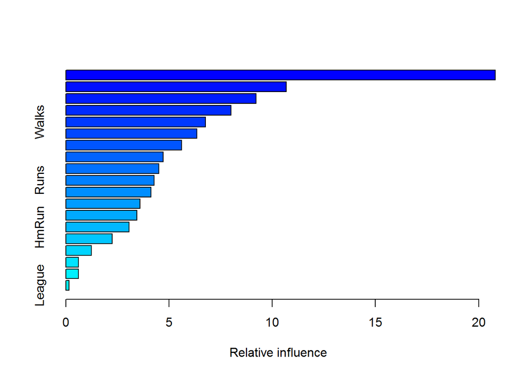

```
##                 var    rel.inf
## CAtBat       CAtBat 20.8013704
## PutOuts     PutOuts 10.6852784
## CRuns         CRuns  9.2134098
## CRBI           CRBI  8.0046341
## Walks         Walks  6.7666683
## CHmRun       CHmRun  6.3541145
## Assists     Assists  5.6015232
## Hits           Hits  4.7212448
## Years         Years  4.4997575
## Runs           Runs  4.2825546
## AtBat         AtBat  4.1282273
## RBI             RBI  3.5885449
## CWalks       CWalks  3.4347548
## HmRun         HmRun  3.0569699
## Errors       Errors  2.2491818
## CHits         CHits  1.2436148
## NewLeague NewLeague  0.6135281
## Division   Division  0.6082381
## League       League  0.1463847
```

```r
set.seed(1)
boost.best = gbm(Salary ~ ., data = Hitters.train, distribution = "gaussian", n.trees = 1000, shrinkage = lambdas[which.min(test.errors)])
summary(boost.best)
```

7. Apply bagging to the training set. What is the test set MSE for this approach?

The test MSE has been tested with different values of ntree, ranging from 500 to 2000, as shown below. The one generating the smallest test MSE is ntree = 1000, with test MSE = 22.93%

```r
library (randomForest)
set.seed(1)

#Generate a random forest model on the training data, with a number of trees set to 1500,
#and the number of variables randonly sampled as candidates (mtry) set to 19 (dim(Hitters.train)[2]-1)
rf.hitters = randomForest(Salary ~ ., data = Hitters.train, ntree = 500, mtry = dim(Hitters.train)[2]-1)
#Generate prediction of the model based on the test set
rf.pred = predict(rf.hitters, Hitters.test)
#Get the test error rate
mean((Hitters.test$Salary - rf.pred)^2)
```

```
## [1] 0.2313593
```

```r
#Generate a random forest model on the training data, with a number of trees set to 1500,
#and the number of variables randonly sampled as candidates (mtry) set to 19 (dim(Hitters.train)[2]-1)
rf.hitters = randomForest(Salary ~ ., data = Hitters.train, ntree = 1000, mtry = dim(Hitters.train)[2]-1)
#Generate prediction of the model based on the test set
rf.pred = predict(rf.hitters, Hitters.test)
#Get the test error rate
mean((Hitters.test$Salary - rf.pred)^2)
```

```
## [1] 0.2293419
```

```r
#Generate a random forest model on the training data, with a number of trees set to 1500,
#and the number of variables randonly sampled as candidates (mtry) set to 19 (dim(Hitters.train)[2]-1)
rf.hitters = randomForest(Salary ~ ., data = Hitters.train, ntree = 1500, mtry = dim(Hitters.train)[2]-1)
#Generate prediction of the model based on the test set
rf.pred = predict(rf.hitters, Hitters.test)
#Get the test error rate
mean((Hitters.test$Salary - rf.pred)^2)
```

```
## [1] 0.2304954
```

```r
#Generate a random forest model on the training data, with a number of trees set to 1500,
#and the number of variables randonly sampled as candidates (mtry) set to 19 (dim(Hitters.train)[2]-1)
rf.hitters = randomForest(Salary ~ ., data = Hitters.train, ntree = 2000, mtry = dim(Hitters.train)[2]-1)
#Generate prediction of the model based on the test set
rf.pred = predict(rf.hitters, Hitters.test)
#Get the test error rate
mean((Hitters.test$Salary - rf.pred)^2)
```

```
## [1] 0.2330813
```

General Conclusion: looking at the results provided by the bagging, Boosting and linear regression, it looks like the Bagging model provides the best prediction power, with a test MSE at 22.93%.

Exercise 11: In this section, Boosting on the Caravan dataset

1. Create a training set containing 1,000 observations, and a test set containing the res.

```r
library(ISLR)
data("Caravan")

#As the Bernouilli requires the response to be in {0,1},
#Then the following piece of code transform the Yes to 1 and No to 0
Caravan$Purchase = ifelse(Caravan$Purchase == "Yes", 1, 0)

#Create the training set with the first 1000 observations
train = 1:1000
Caravan.train = Caravan[train, ]
dim(Caravan.train)
```

```
## [1] 1000   86
```

```r
#The test set contains the rest of the data
Caravan.test = Caravan[-train, ]
dim(Caravan.test)
```

```
## [1] 4822   86
```

2. Fit the Boosting model to the training set with Purchase as the response and the other variables as predictors. Use 1000 trees, and a shrinkage value of 0.01. Which predictors appear to be the most important?

Looking at the summary() function results, and assuming we want to retain only the three main predictors (highest level of influence), then the most influential predictors are: PPERSAUT (14.63), MKOOPKLA(9.47) and MOPLHOOG(7.31).

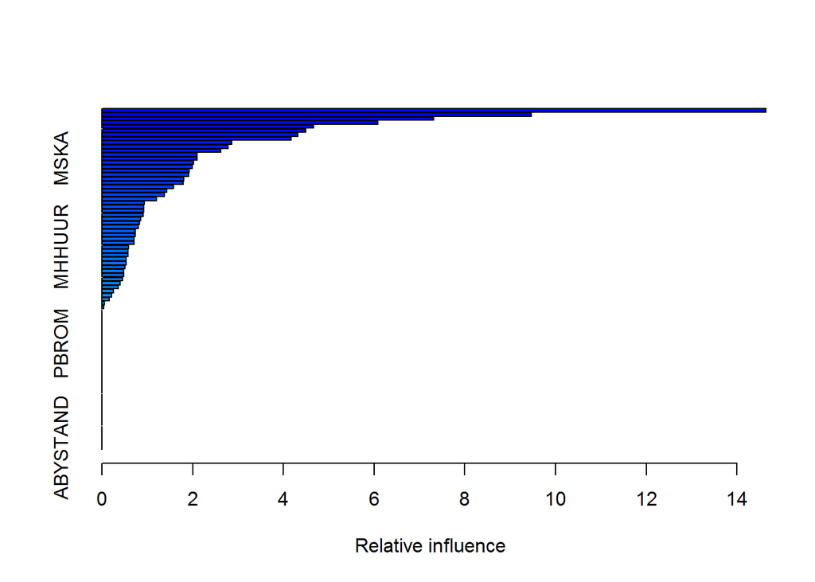

```
##               var     rel.inf
## PPERSAUT PPERSAUT 14.63504779
## MKOOPKLA MKOOPKLA  9.47091649
## MOPLHOOG MOPLHOOG  7.31457416
## MBERMIDD MBERMIDD  6.08651965
## PBRAND     PBRAND  4.66766122
## MGODGE     MGODGE  4.49463264
## ABRAND     ABRAND  4.32427755
## MINK3045 MINK3045  4.17590619
## MOSTYPE   MOSTYPE  2.86402583
## PWAPART   PWAPART  2.78191075
## MAUT1       MAUT1  2.61929152
## MBERARBG MBERARBG  2.10480508
## MSKA         MSKA  2.10185152
## MAUT2       MAUT2  2.02172510
## MSKC         MSKC  1.98684345
## MINKGEM   MINKGEM  1.92122708
## MGODPR     MGODPR  1.91777542
## MBERHOOG MBERHOOG  1.80710618
## MGODOV     MGODOV  1.78693913
## PBYSTAND PBYSTAND  1.57279593
## MSKB1       MSKB1  1.43551401
## MFWEKIND MFWEKIND  1.37264255
## MRELGE     MRELGE  1.20805179
## MOPLMIDD MOPLMIDD  0.93791970
## MINK7512 MINK7512  0.92590720
## MINK4575 MINK4575  0.91745993
## MGODRK     MGODRK  0.90765539
## MFGEKIND MFGEKIND  0.85745374
## MZPART     MZPART  0.82531066
## MRELOV     MRELOV  0.80731252
## MINKM30   MINKM30  0.74126812
## MHKOOP     MHKOOP  0.73690793
## MZFONDS   MZFONDS  0.71638323
## MAUT0       MAUT0  0.71388052
## MHHUUR     MHHUUR  0.59287247
## APERSAUT APERSAUT  0.58056986
## MOSHOOFD MOSHOOFD  0.58029563
## MSKB2       MSKB2  0.53885275
## PLEVEN     PLEVEN  0.53052444
```

[output cut: 31 more lines]

```
## AMOTSCO   AMOTSCO  0.00000000
## AVRAAUT   AVRAAUT  0.00000000
## AAANHANG AAANHANG  0.00000000
## ATRACTOR ATRACTOR  0.00000000
## AWERKT     AWERKT  0.00000000
## ABROM       ABROM  0.00000000
## ALEVEN     ALEVEN  0.00000000
## APERSONG APERSONG  0.00000000
## AGEZONG   AGEZONG  0.00000000
## AWAOREG   AWAOREG  0.00000000
## AZEILPL   AZEILPL  0.00000000
## APLEZIER APLEZIER  0.00000000
## AFIETS     AFIETS  0.00000000
## AINBOED   AINBOED  0.00000000
## ABYSTAND ABYSTAND  0.00000000
```

```r
library(gbm)
set.seed(1)
#As this is a classification problem, the distribution is set to "bernoulli", for a regression problem it would be set to 'gaussian'
#The gbm() function fit the purchase variable against all other predictors on the training set Caravan.Train, with a tree number set to 1000
#and a shrinkage of 0.01
boost.caravan = gbm(Purchase ~ ., data = Caravan.train, n.trees = 1000, shrinkage = 0.01, distribution = "bernoulli")
#The summary() function prodives ordered list of most influencial to least influencial predictors.
summary(boost.caravan)
```

3. Use the Boosting model to predict the response on the test data. Predict that a person will make a purchase if the estimated probability of purchase is greater than 20%. Form a confusion matrix. What fraction of the people predicted to make a purchase do in fact make one? How does this compare with the results obtained from applying KNN or Logisitic Regression to this data set?

Looking at the confusion matrix for the Boosting model, it can be deduced that ‘people predicted to make a purchase do in fact make one’ represents 21.15%

Looking at the confusion matrix for the Logistic Regression model, it can be deduced that ‘people predicted to make a purchase do in fact make one’ represents 14.22%

```r
set.seed(1)
#This is the Boosting model to predict the response on the test data
boost.prob = predict(boost.caravan, Caravan.test, n.trees = 1000, type = "response")
#Predict that a person will make a purchase if the estimated probability of purchase is greater than 20%.
boost.pred = ifelse(boost.prob > 0.2, 1, 0)
#Generate the confusion matrix
table(Caravan.test$Purchase, boost.pred)
```

```
##    boost.pred
##        0    1
##   0 4410  123
##   1  256   33
```

```r
cat("Boosting purchase prediction: ",  100 * 33/(123+33),"%")
```

```
## Boosting purchase prediction:  21.15385 %
```

```r
#Now applying a Logistic Regression
#Model training
lm.caravan = glm(Purchase ~ ., data = Caravan.train, family = binomial)
#Model prediction
lm.prob = predict(lm.caravan, Caravan.test, type = "response")
lm.pred = ifelse(lm.prob > 0.2, 1, 0)
#Generate the confusion matrix
table(Caravan.test$Purchase, lm.pred)
```

```
##    lm.pred
##        0    1
##   0 4183  350
##   1  231   58
```

```r
cat("Boosting purchase prediction: ",  100 * 58/(350+58),"%")
```

```
## Boosting purchase prediction:  14.21569 %
```

Week 10: Build a Ridge and a Lasso model for the problem considered in Excercise 10 from Chapter 8 of Tibshirani’s ISLR book, with particular values of the models’ parameters chosen by you. Then tune/optimise the models with cross validation. Compare your optimised Ridge and Lasso models with the models you developed in point (e) of the above mentioned exercise, and choose the best one justifying your choice.

PART A - THE RIDGE REGRESSION MODEL

Ridge model creation & computation of the MSEs based on a number of manually selected lambdas. The results show that the min test MSE of 36.3% is obtained with a lambda = 0.01.

```r
library(glmnet)
library(ISLR)
cat ("Nb of predictors:", length(Hitters)-1)
```

```
## Nb of predictors: 19
```

```r
set.seed(1)

#The model() function is used to create x. It produces two things:
#1) a matrix of corresponding 19 predictors
#2) it transforms any quantitative variables into dummy variables (this is important as glmnet can only take numerical variables)
x = model.matrix(Salary ~ ., data = Hitters)[,-1]
#This is represents the log(Salary), as it was generated above in the Exercise 10 a)
y = Hitters$Salary

#Define training and test set in line with exercise 10
#The first 200 rows belong to the training dataset, the rest to the test set
train = sample(1:nrow(x),200)
test = (-train)
y.test = y[test]

#The gmnlet() function takes an alpha argument (alpha = 0: ridge regression model, alpha = 1:  lasso regression model)
#The gmnlet() function set by default to standardize=TRUE which ensures all variables are on the same scale.
#The gmnlet() function performs ridge regression for an automatically selected range of lambda values.
#However, in this case the lambda range has been selected between 10^10 and 10^-2. This range covers the full range of scenarios from the null model containing only the intercept, to the least square fit.
#The ridge regression is performed on the training set
grid = 10^seq(10,-2,length=100)
ridge.mod = glmnet(x[train,],y[train],alpha=0,lambda = grid)
#Associated with each value of lambda, there is a vector of ridge regression coefficients, stored in a matrix accessed by the coef() mehod. In this case, a 20X100 matrix, 20 rows (one for each predictor and the intercept) and 100 columns (one for each value of lambda)
dim(coef(ridge.mod))
```

```
## [1]  20 100
```

```r
cat("Print MSE for a number of selected lambdas")
```

```
## Print MSE for a number of selected lambdas
```

```r
generate_ridge_mse_from_selected_lambda = function(index) {
  lambda = ridge.mod$lambda[index]
  ridge.pred = predict(ridge.mod,s=lambda, newx=x[test,])
  mse = mean((ridge.pred-y.test)^2)
  cat("Ridge MSE: ", 100*mse,"% for lambda = ", lambda )
}

generate_ridge_mse_from_selected_lambda(1)
```

```
## Ridge MSE:  76.4011 % for lambda =  1e+10
```

```r
generate_ridge_mse_from_selected_lambda(25)
```

```
## Ridge MSE:  76.40106 % for lambda =  12328467
```

```r
generate_ridge_mse_from_selected_lambda(50)
```

```
## Ridge MSE:  76.35675 % for lambda =  11497.57
```

```r
generate_ridge_mse_from_selected_lambda(75)
```

```
## Ridge MSE:  51.80087 % for lambda =  10.72267
```

```r
generate_ridge_mse_from_selected_lambda(100)
```

```
## Ridge MSE:  36.31307 % for lambda =  0.01
```

Cross-validation best lambda selection to optimise the model:

The results that the best selected lambda by cross-validation is 0.2461. This is the lambda value that minimise the MSE. This is observable on the graph as well.

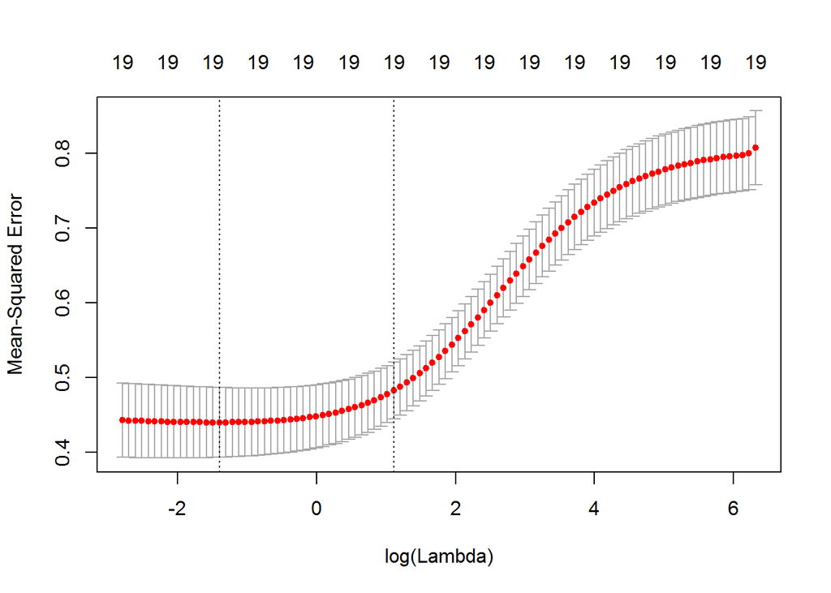

```r
#By default the cv.glmnet() function performs a ten-fold cross-validation
set.seed(1)
cv.out = cv.glmnet(x[train,], y[train], alpha=0)
plot(cv.out)
```

```r
bestlambda=cv.out$lambda.min
cat ("Best selected lambda by cross-validation: ", bestlambda)
```

```
## Best selected lambda by cross-validation:  0.2461349
```

The test MSE can be generated with the best selected lambda. The test MSE is 34.40% for the best lambda = 0.2461 in a Ridge Regression setting.

```r
set.seed(1)
ridge.pred = predict(ridge.mod,s=bestlambda, newx=x[test,])
mean((ridge.pred-y.test)^2)
```

```
## [1] 0.3440014
```

PART B - THE LASSO REGRESSION MODEL

The below section builds the lasso regression model

Lasso model creation & computation of the MSEs based on a number of manually selected lambdas. The results show that the test MSE of 36.15% is obtained with a lambda = 0.01.

```r
set.seed(1)
#The gmnlet() function takes an alpha argument (alpha = 0: ridge regression model, alpha = 1:  lasso regression model)
#The gmnlet() function set by default standardize=TRUE which ensure all variables are on the same scale.
#The gmnlet() function performs ridge regression for an automatically selected range of lambda values. However, in this
#case the lambda range has been selected between 10^10 and 10^-2. This range covers the full range of scenarios from the null model containing only the intercept, to the least square fit.
#The ridge regression is performed on the training set
grid = 10^seq(10,-2,length=100)
lasso.mod = glmnet(x[train,],y[train],alpha=1,lambda = grid)
#Associated with each value of lambda, there is a vector of ridge regression coefficients, stored in a matrix accessed by the coef() mehod. In this case, a 20X100 matrix, 20 rows (one for each predictor and the intercept) and 100 columns (one for each value of lambda)
dim(coef(lasso.mod))
```

```
## [1]  20 100
```

```r
cat("Print MSE for a number of selected lambdas")
```

```
## Print MSE for a number of selected lambdas
```

```r
generate_lasso_mse_from_selected_lambda = function(index) {
  lambda = lasso.mod$lambda[index]
  lasso.pred = predict(lasso.mod,s=lambda, newx=x[test,])
  mse = mean((lasso.pred-y.test)^2)
  cat("Lasso MSE : ", 100*mse,"% for lambda = ", lambda )
}

generate_lasso_mse_from_selected_lambda(1)
```

```
## Lasso MSE :  76.4011 % for lambda =  1e+10
```

```r
generate_lasso_mse_from_selected_lambda(25)
```

```
## Lasso MSE :  76.4011 % for lambda =  12328467
```

```r
generate_lasso_mse_from_selected_lambda(50)
```

```
## Lasso MSE :  76.4011 % for lambda =  11497.57
```

```r
generate_lasso_mse_from_selected_lambda(75)
```

```
## Lasso MSE :  76.4011 % for lambda =  10.72267
```

```r
generate_lasso_mse_from_selected_lambda(100)
```

```
## Lasso MSE :  36.15047 % for lambda =  0.01
```

Cross-validation best lambda selection to optimise the model:

The results that the best selected lambda by cross-validation is 0.02349477. This is the lambda value that minimise the MSE.

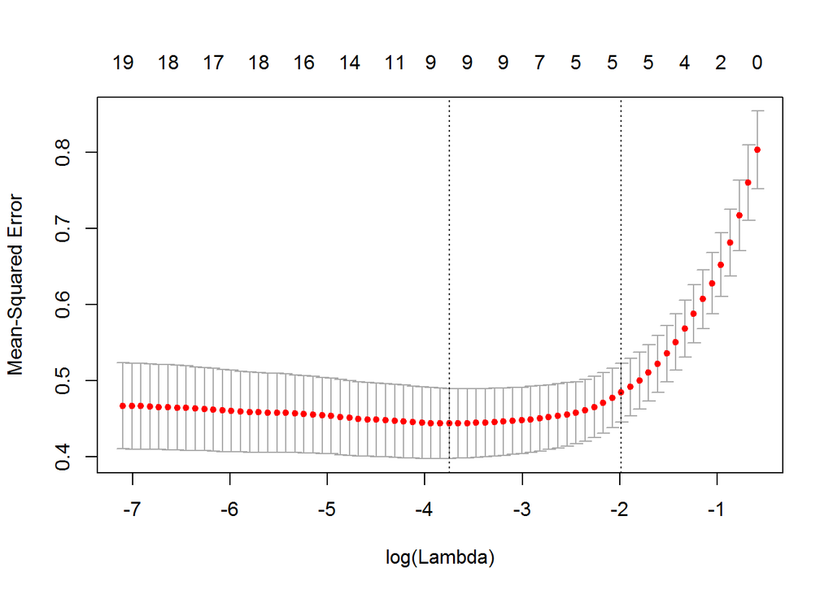

```r
#The variables/vectors train, test and y.test are defined in PART A
#By default the cv.glmnet() function performs a ten-fold cross-validation
set.seed(1)

#Generate the lasso regression model (alpha=1)
cv.out_lasso = cv.glmnet(x[train,], y[train], alpha=1)
plot(cv.out_lasso)
```

```r
bestlambda_lasso=cv.out_lasso$lambda.min
cat ("Best selected lambda by cross-validation: ", bestlambda_lasso)
```

```
## Best selected lambda by cross-validation:  0.02349477
```

```r
set.seed(1)
lasso.pred = predict(lasso.mod,s=bestlambda_lasso, newx=x[test,])
mean((lasso.pred-y.test)^2)
```

```
## [1] 0.3561521
```

Conclusion:

It looks like the Bagging model is the winner with a test MSE at 22.93%.

As mentioned before, this error rate is still large. Predicting correctly the salary level, on average at 77.1% based on all predictors might be acceptable for this use case. However, this indicates that important factors are not taken into account. It would be interesting to add more predictors that might have an impact on the Salary regressor, and establish whether we can improve the model.

## File Location:

```r
setwd("C:\\Users\\Fred\\Desktop\\Studies\\MSc-DataScience\\Statistical Learning\\Assignments\\Assignment1")
```

# Un-comment below line to generate html

render(“Assignment_MLSDM_v6_Frederic_Marechal_md.Rmd”)